# Two-Sample Tests: Lecture Notes

# 9 $Q$-$Q$ Plots and the $K$-$S$ Test

## 9.1 Two-Sample $Q$-$Q$ Plots

Plot the quantiles of $X$ against the quantiles of $Y$. If $F = G$ the points fall on the line $y = x$.

| Pattern | Interpretation |
| --- | --- |
| Parallel line (shifted) | Location shift |
| Line through origin, slope $\ne 1$ | Scale shift |
| Curved | Shape difference |

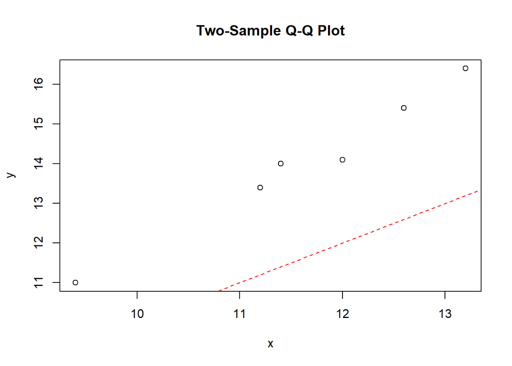

```r
qqplot(x, y, main = "Two-Sample Q-Q Plot")
abline(0, 1, col = "red", lty = 2)
```

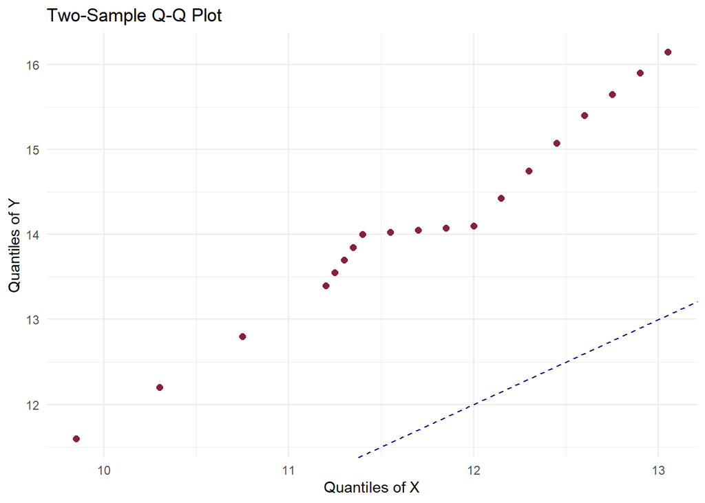

```r
df_qq <- data.frame(
  xq = quantile(x, probs = seq(0.05, 0.95, 0.05)),
  yq = quantile(y, probs = seq(0.05, 0.95, 0.05))
)
library(ggplot2)
ggplot(df_qq, aes(xq, yq)) +
  geom_point(size = 2, color = "#861F41") +
  geom_abline(slope = 1, intercept = 0, color = "navy", linetype = 2) +
  labs(x = "Quantiles of X", y = "Quantiles of Y",
       title = "Two-Sample Q-Q Plot") +
  theme_minimal()
```

## 9.2 Kolmogorov-Smirnov Two-Sample Test

$$KS = \sup_x \left|\hat{F}_X(x) - \hat{G}_Y(x)\right|$$

$H_0: F_X = G_Y$. An **omnibus test** — detects location, scale, or shape differences.

```r
ks.test(x, y)           # two-sample
```

```
    Exact two-sample Kolmogorov-Smirnov test

data:  x and y
D = 0.83333, p-value = 0.02597
alternative hypothesis: two-sided
```

```r
ks.test(x, "pnorm")     # one-sample goodness-of-fit for N(0,1)
```

```
    Exact one-sample Kolmogorov-Smirnov test

data:  x
D = 1, p-value < 2.2e-16
alternative hypothesis: two-sided
```

The normalized statistic converges to a **Brownian bridge**:

$$\frac{KS}{\sqrt{1/m + 1/n}} \xrightarrow{d} \sup_{0 \le t \le 1} |B(t)|$$

# 10 Randomized Tests

## 10.1 The Discreteness Problem

For a discrete test statistic, the Type I error can only take a limited number of values, so you cannot achieve *exactly* any target $\alpha$.

**Example:** $X \sim \text{Binomial}(5, \theta)$, $H_0: \theta = 1/2$.

| $c$ | 5 | 4 | 3 | 2 | 1 | 0 |
| --- | --- | --- | --- | --- | --- | --- |
| $P(X \ge c \mid \theta = 1/2)$ | $1/32$ | $6/32$ | $16/32$ | $26/32$ | $31/32$ | 1 |

Rejecting when $X = 5$ gives exact size $1/32 = 0.03125 \ne 0.05$.

## 10.2 Randomized Rule

Introduce randomization at the boundary: reject with probability $p \in (0,1)$ at the critical boundary, chosen so that:

$$\alpha = P(T \ge t_2) + p \cdot P(t_1 \le T < t_2)$$

This is mainly a **theoretical tool** to make the ARE framework rigorous.

# 11 Van der Waerden and Linear Rank Tests

## 11.1 Linear Rank Statistics

$$T = \sum_{i=1}^N a_i Z_i, \quad Z_i = \mathbf{1}[\text{$i$-th position is from group $X$}]$$

| Test | Weights $a_i$ | Best for |
| --- | --- | --- |
| Wilcoxon | $i$ | General location |
| Van der Waerden | $\Phi^{-1}\!\left(\frac{i}{N+1}\right)$ | $N(\mu,\sigma^2)$ location ($\text{ARE} = 1$ with $t$) |
| Siegel-Tukey | Alternating from extremes | Scale |

# 12 Difference-in-Differences

## 12.1 From Two-Sample Tests to DiD

Two-sample tests compare **two groups at one time point**. **Difference-in-Differences (DiD)** extends this to a before/after, treatment/control design:

$$\hat{\tau}_{DiD} = \underbrace{\left(\bar{Y}_{T,\text{after}} - \bar{Y}_{T,\text{before}}\right)}_{\text{change in treatment}} - \underbrace{\left(\bar{Y}_{C,\text{after}} - \bar{Y}_{C,\text{before}}\right)}_{\text{change in control}}$$

**Key assumption:** *parallel trends* — without treatment, both groups would have changed by the same amount.

$$\begin{array}{lccc}
& \text{Before} & \text{After} & \text{Change} \\
\hline
\text{Control} & \mu_{C0} & \mu_{C1} & \mu_{C1} - \mu_{C0} \\
\text{Treated} & \mu_{T0} & \mu_{T1} & \mu_{T1} - \mu_{T0} \\
\hline
\hat{\tau}_{DiD} & & & (\mu_{T1}-\mu_{T0}) - (\mu_{C1}-\mu_{C0}) \\
\end{array}$$

## 12.2 Base R Example

```r
set.seed(42)
did_data <- data.frame(
  unit    = rep(1:20, 2),
  time    = rep(c("before", "after"), each = 20),
  treated = rep(c(rep(0, 10), rep(1, 10)), 2),
  outcome = c(rnorm(10, 5), rnorm(10, 5),   # before: both N(5, 1)
              rnorm(10, 5), rnorm(10, 8))    # after: control N(5,1), treated N(8,1)
)
# "before" as reference level
did_data$time <- factor(did_data$time, levels = c("before", "after"))
```

```r
# The interaction timeafter:treated IS the DiD estimator
fit <- lm(outcome ~ time + treated + time:treated, data = did_data)
summary(fit)
```

```
Call:
lm(formula = outcome ~ time + treated + time:treated, data = did_data)

Residuals:
    Min      1Q  Median      3Q     Max
-2.4930 -0.6180 -0.1181  0.8350  2.4501

Coefficients:
                  Estimate Std. Error t value Pr(>|t|)
(Intercept)         5.5473     0.3853  14.399  < 2e-16 ***
timeafter          -0.7254     0.5448  -1.331    0.191
treated            -0.7108     0.5448  -1.305    0.200
timeafter:treated   3.5249     0.7705   4.575 5.47e-05 ***
---
Signif. codes:  0 '***' 0.001 '**' 0.01 '*' 0.05 '.' 0.1 ' ' 1

Residual standard error: 1.218 on 36 degrees of freedom
Multiple R-squared:  0.4974,    Adjusted R-squared:  0.4555
F-statistic: 11.88 on 3 and 36 DF,  p-value: 1.481e-05
```

```r
# Equivalent manual calculation
means <- tapply(did_data$outcome,
                list(did_data$time, did_data$treated), mean)
means
```

```
              0        1
before 5.547297 4.836543
after  4.821920 7.636096
```

```r
did_est <- (means["after", "1"] - means["before", "1"]) -
           (means["after", "0"] - means["before", "0"])
did_est
```

```
[1] 3.524929
```

## 12.3 Connection to Two-Sample Testing

|  | Two-sample $t$-test | DiD |
| --- | --- | --- |
| Design | Cross-section | Panel / before-after |
| Comparison | Treated vs control | Change in treated vs change in control |
| Controls for | Observed differences | Time-invariant confounders $+$ time trends |
| Key assumption | Exchangeability | Parallel trends |

# 13 Summary of Tests

| Test | Type | $H_0$ | Key assumption |
| --- | --- | --- | --- |
| Two-sample $t$ (equal var) | Parametric | $\mu_X = \mu_Y$ | $N(\mu,\sigma^2)$, $\sigma_X^2 = \sigma_Y^2$ |
| Welch $t$ | Parametric | $\mu_X = \mu_Y$ | $N(\mu,\sigma^2)$ (approximate) |
| Permutation | Nonparametric | $F_X = F_Y$ | Exchangeability |
| Wilcoxon rank-sum | Nonparametric | $\Delta = 0$ | Continuity |
| $F$-test | Parametric | $\sigma_X^2 = \sigma_Y^2$ | $N(\mu,\sigma^2)$ |
| Siegel-Tukey | Nonparametric | $\sigma_X = \sigma_Y$ | Equal medians |
| $K$-$S$ test | Nonparametric | $F_X = G_Y$ | Continuity |

# 14 References

- Gibbons, J.D. & Chakraborti, S. (2011). *Nonparametric Statistical Inference*, 5th ed. CRC Press.
- Hollander, M., Wolfe, D.A. & Chicken, E. (2014). *Nonparametric Statistical Methods*, 3rd ed. Wiley.
- Conover, W.J. (1999). *Practical Nonparametric Statistics*, 3rd ed. Wiley.
- Angrist, J.D. & Pischke, J.S. (2009). *Mostly Harmless Econometrics*. Princeton University Press.
- OpenIntro Statistics data: https://www.openintro.org/data/